# INFORME TECNICO OBRA ACUEDUCTO ALBAN

## HITO No 1: CONSTRUCCIÓN DE BOCATOMA

Especificaciones Técnicas y Georreferenciación de la Bocatoma Auxiliar

1. Localización y Dimensionamiento

La estructura proyectada se localiza en la vereda Aguacillas, identificada satelitalmente (Google Earth) en las coordenadas **Latitud 1°31'46.31"N y Longitud 77°0'14.47"O**. El proyecto contempla un **área de construcción efectiva de 20 m²** para la bocatoma auxiliar. Este dimensionamiento responde a un análisis riguroso de la topografía del emplazamiento y del comportamiento hidráulico del afluente, garantizando así una captación eficiente y la estabilidad hidrodinámica requerida durante la ejecución de las obras de protección definitiva.

2. Control Geodésico (Normativa IGAC)

Para garantizar la precisión posicional, el replanteo se rige por los lineamientos del **Instituto Geográfico Agustín Codazzi (IGAC)**. Se ha realizado la densificación de dos puntos de control (mojones con placas de aluminio) vinculados a la **estación permanente IGAC PASTO (PSTO)**. Las coordenadas ajustadas al sistema **MAGNA SIRGAS (Origen 2018)** son:

- **📍 PUNTO GPS-1:**  
  Norte: 660336.520 m | Este: 1008098.930 m | Altura: 2490.443 msnm.  
  *(Lat: 1°31'28.07"N - Long: 77°00'17.10"W)*

- **📍 PUNTO GPS-2:**  
  Norte: 660274.213 m | Este: 1008116.379 m | Altura: 2496.313 msnm.  
  *(Lat: 1°31'26.04"N - Long: 77°00'16.54"W)*

3. Diseño Hidráulico-Estructural

El diseño tiene como objetivo asegurar la **continuidad operativa del sistema de aducción** del Acueducto Regional, mitigando el riesgo de interrupción del servicio mientras se desarrollan las labores de estabilización en el punto crítico. Asimismo, la geometría adoptada optimiza el balance de materiales, permitiendo la incorporación de agregados pétreos locales y facilitando los procesos constructivos.

Para garantizar la durabilidad de la obra, la estructura principal se integra con sistemas de protección complementarios, tales como **solados en concreto ciclópeo y confinamientos en gaviones**. Estas obras conexas cumplen la función de controlar los fenómenos de socavación, regular la velocidad de aproximación del flujo y salvaguardar la integridad estructural de la infraestructura de captación adyacente.

### 1.1 OBRAS PRELIMINARES

#### 1.1.1. localización y replanteo de estructuras.

Este item se refiere a ubicar y marcar en el terreno o superficie de construcción los ejes principales, paralelos y perpendiculare señalados en el plano del proyecto, asi como los linderos del mismo.

```
Generando miniaturas...
```

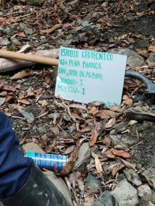

Imagen No 1

[figure not shown]

Imagen No 2

| ITEM | DETALLE | UNIDAD | CANTIDAD BIM |
| --- | --- | --- | --- |
| 1.1.1 | localización y replanteo de estructuras | m2 | 19.117103 |

### 1.2. EXCAVACIÓN MANUAL EN MATERIAL DE RÍO

- La **excavación manual en material de río** comprende la remoción control de sedimentos, gravas y arenas localizadas en el cauce o en la zona destinada para la captación. Para ello se emplean herramientas menores como palas, picas y baldes, lo que permite un manejo preciso del terreno y una intervención de bajo impacto.
- Este procedimiento se ejecuta siguiendo estrictamente las cotas, alineamientos y dimensiones establecidos en los planos constructivos, asegurando la estabilidad del área intervenida y evitando alteraciones que puedan comprometer el funcionamiento hidráulico del sistema o generar procesos erosivos.
- La actividad es desarrollada por personal capacitado, con el fin de minimizar la alteración del cauce natural y prevenir el arrastre involuntario de material hacia sectores aguas abajo. Este enfoque garantiza el cumplimiento de los lineamientos ambientales y de manejo del recurso hídrico.
- El material producto de la excavación se acopia y dispone en sitios previamente definidos por la interventoría, conforme a las especificaciones técnicas y ambientales del proyecto, evitando así obstrucciones, contaminación o afectaciones al entorno inmediato.

```
Generando miniaturas...
```

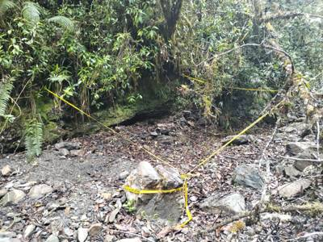

Imagen No 4

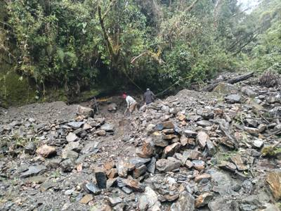

Imagen No 5

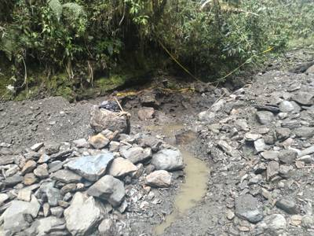

Imagen No 6

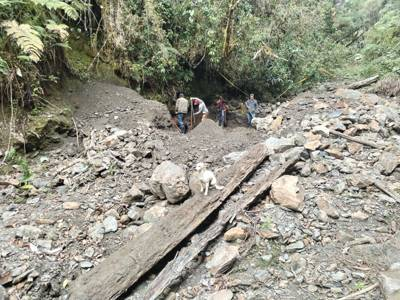

Imagen No 7

| ITEM | DETALLE | UNIDAD | CANTIDAD BIM |
| --- | --- | --- | --- |
| 1.2.1.1 | Excavación manual | m3 | 34.410785 |
| 1.2.1.2 | Limpieza manual | m3 | 22.367010 |

### 1.3. OBRAS EN CONCRETO

#### 1.3.1. Obras en Concreto Simple

Esta sección comprende todas las actividades necesarias para la ejecución de elementos constructivos en concreto simple (elementos no estructurales o con refuerzo mínimo por temperatura). El alcance de la actividad incluye el suministro de materiales, transporte, mano de obra calificada, equipo y herramienta menor indispensables para la correcta dosificación, mezcla, vaciado, vibrado, curado y acabado final, garantizando el cumplimiento de las dimensiones, alineamientos y especificaciones establecidas en los planos del proyecto.

#### 1.3.1.1. Concreto para Solado (f'c = 14 MPa)

Descripción: Consiste en la elaboración y colocación de una capa de concreto pobre con una resistencia a la compresión de 14 MPa (aproximadamente 2000 psi) a los 28 días. Este elemento actúa como superficie de limpieza, nivelación y transición entre el terreno natural excavado y la estructura proyectada (Bocatoma Auxiliar y obras de protección).

```
Generando miniaturas...
```

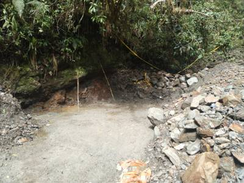

#### 1.3.1.2. Concreto ciclópeo 50 % piedra de 12” y 50 % concreto de 21 MPa

El **concreto ciclópeo** está conformado por una mezcla de concreto de **21 MPa** combinada con **piedra de 12 pulgadas** en una proporción del **50 %**, lo que permite aumentar la estabilidad y reducir el consumo de cemento en estructuras de gran volumen.  
Este tipo de concreto se emplea en los muros de contención, solados y obras de protección hidráulica, ofreciendo una alta resistencia frente a la socavación y la erosión del terreno.

```
Analizando archivos...
Se encontraron 1 imágenes. Procesando...
```

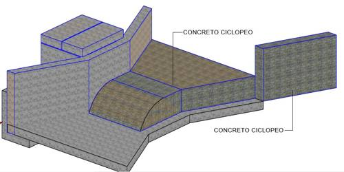

Imagen No 10

| ITEM | DETALLE | UNIDAD | CANTIDAD BIM |
| --- | --- | --- | --- |
| 1.3.1.1 | Concreto para solado 14 Mpa | m3 | 2.868000 |
| 1.3.1.2 | Concreto Ciclópeo 50 % piedra 12" y 50% Concreto de 21 Mpa | m3 | 3.441079 |

### 1.3.2. OBRAS EN CONCRETO ESTRUCTURAL

#### 1.3.2.1. Concreto Impermeabilizado para Muros ($f'c = 28$ MPa)

Descripción y Alcance: Este ítem comprende el suministro, transporte, colocación y curado de concreto estructural reforzado con una resistencia a la compresión de $f'c = 28$ MPa (4000 psi), adicionado con impermeabilizante integral. Su aplicación específica corresponde a la construcción de los muros de la bocatoma, incluyendo aletas de encauzamiento, muros de contención lateral y pantallas de la estructura de captación, conforme a las dimensiones y geometrías detalladas en el modelado BIM y los planos estructurales.

Especificaciones del Material:

- Resistencia: El concreto deberá garantizar una resistencia de 28 MPa a los 28 días.
- Consistencia: El asentamiento (slump) deberá ser el adecuado para permitir el llenado completo de las formaletas en muros delgados o densamente armados sin segregar.

```
Analizando archivos...
Se encontraron 1 imágenes. Procesando...
```

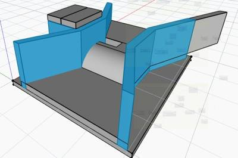

Imagen No 11

#### 1.3.2.2. Concreto Impermeabilizado para placa Inferior - 28 Mpa.

Descripción: Suministro, colocación y acabado de concreto estructural de $f'c = 28$ MPa (4000 psi) con aditivo impermeabilizante integral, destinado a la construcción de la losa de fondo o solera de la bocatoma.

Funcionalidad.

- Estructural: Actúa como cimentación monolítica, transmitiendo las cargas de los muros y la presión del agua al terreno.
- Hidráulica: Provee una superficie resistente a la abrasión por arrastre de sedimentos y garantiza la estanqueidad del fondo para evitar subpresiones o infiltraciones.

```
Analizando archivos...
Se encontraron 1 imágenes. Procesando...
```

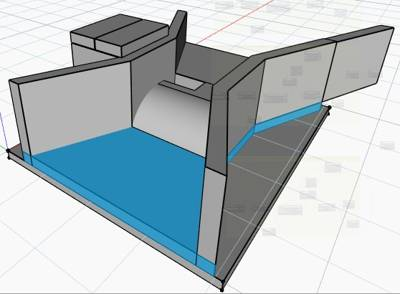

Imagen No 12

### 1.3.2.3. Concreto Impermeabilizado para placa superior tanque desviador- 28 Mpa

```
Analizando archivos...
Se encontraron 1 imágenes. Procesando...
```

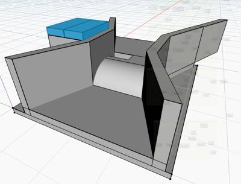

Imagen No 13

### FOTOS: OBRAS EN CONCRETO ESTRUCTURAL.

```
Generando miniaturas...
```

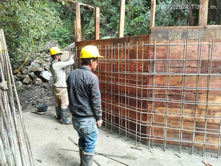

Imagen No 14

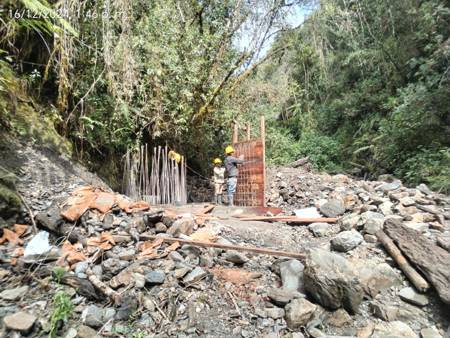

Imagen No 15

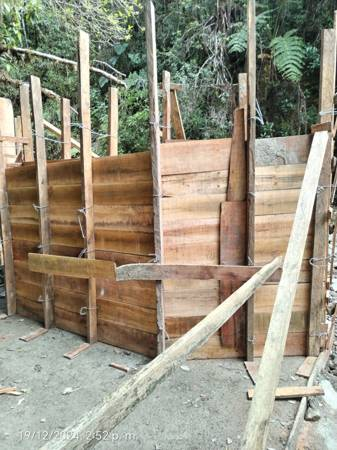

Imagen No 16

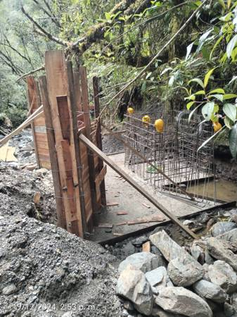

Imagen No 17

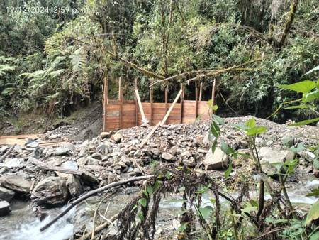

Imagen No 18

[figure not shown]

Imagen No 19

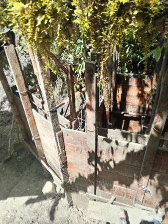

Imagen No 20

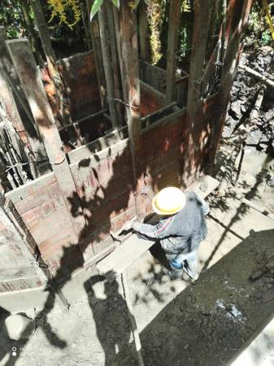

Imagen No 21

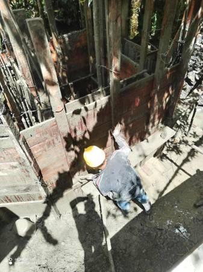

Imagen No 22

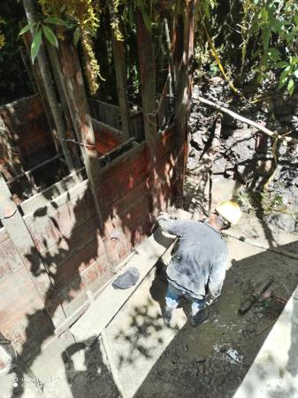

Imagen No 23

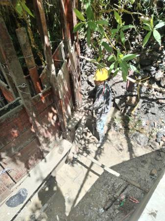

Imagen No 24

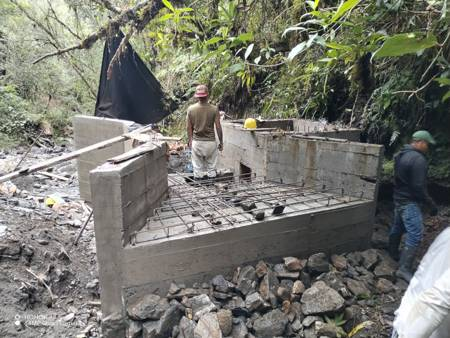

Imagen No 25

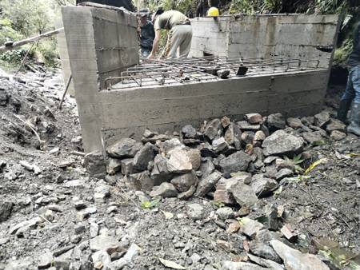

Imagen No 26

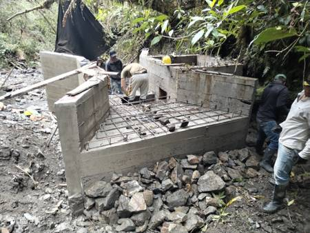

Imagen No 27

[figure not shown]

Imagen No 28

[figure not shown]

Imagen No 29

[figure not shown]

Imagen No 30

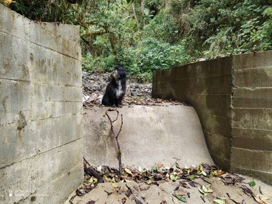

Imagen No 31

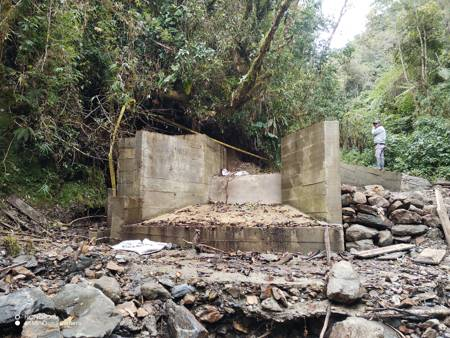

Imagen No 32

| ITEM | DETALLE | UNIDAD | Cantidad BIM |
| --- | --- | --- | --- |
| 1.3.2.1 | Concreto Impermeabilizado para muros. - 28 Mpa | m3 | 4.304591 |
| 1.3.2.2 | Concreto Impermeabilizado para placa Inferior - 28 Mpa | m3 | 2.339907 |
| 1.3.2.3 | Concreto Impermeabilizado para placa superior tanques desviador- 28 Mpa | m3 | 0.924940 |